# Postman

## Postman Interview Project

#### The data we have at hand has the following columns

Columns - ['transaction id', 'product id', 'product description', 'quantity sold', 'transaction timestamp', 'unit price', 'customer id', 'transaction country']

#### Some questions we want to answer looking at the data are

- Is the company's performance improving or degrading over time?
- Examine and highlight important trends visible in the sales data and insights.
- How can we measure our performance in terms of customer acquisition and building customer loyalty?

**Importing necessary libraries**

- numpy
- pandas
- matplotlib

**Note : all libraries are open source libraries**

```python
import numpy as np # linear algebra
import pandas as pd # data processing
```

```python
df = pd.read_excel('Downloads/sales_data.xlsx')
df[140:145]
```

|  | transaction id | product id | product description | quantity sold | transaction timestamp | unit price | customer id | transaction country |
| --- | --- | --- | --- | --- | --- | --- | --- | --- |
| 140 | 536381 | 21523 | DOORMAT FANCY FONT HOME SWEET HOME | 10 | 2010-12-01 09:41:00 | 6.75 | 15311.0 | United Kingdom |
| 141 | C536379 | D | Discount | -1 | 2010-12-01 09:41:00 | 27.50 | 14527.0 | United Kingdom |
| 142 | 536382 | 10002 | INFLATABLE POLITICAL GLOBE | 12 | 2010-12-01 09:45:00 | 0.85 | 16098.0 | United Kingdom |
| 143 | 536382 | 21912 | VINTAGE SNAKES & LADDERS | 8 | 2010-12-01 09:45:00 | 3.75 | 16098.0 | United Kingdom |
| 144 | 536382 | 21832 | CHOCOLATE CALCULATOR | 12 | 2010-12-01 09:45:00 | 1.65 | 16098.0 | United Kingdom |

**Insights about data**

- The data provided in the form on the sales data has a total of 541909 entries.
- Out of these 9288 entries are for cancelled transactions.
- This leaves us with a total of 532621 entries.
- Out of these 532621 entries, we are cleansing entries where the unit price or quantity sold was lesser than 0.
- This leaves us with a total of 531283 entries , which pertain to 20726 unique transactions.

```python
beforeDeleting = df.shape
patternDel = '^C[0-9][0-9][0-9][0-9][0-9][0-9]'
indextoDelete = df[df['transaction id'].str.contains(patternDel)==True].index
# Delete these row indexes from dataFrame
df.drop(indextoDelete,inplace=True)
df.reset_index(inplace=True)
df = df.drop(['index'],axis=1)
```

```python
indextoDelete = df[(df['quantity sold'] < 0)==True].index
# Delete these row indexes from dataFrame
df.drop(indextoDelete,inplace=True)
df.reset_index(inplace=True)
df = df.drop(['index'],axis=1)
```

```python
indextoDelete = df[(df['unit price'] < 0)==True].index
# Delete these row indexes from dataFrame
df.drop(indextoDelete,inplace=True)
df.reset_index(inplace=True)
df = df.drop(['index'],axis=1)
```

```python
after_deleting=df.shape
df[140:145]
```

|  | transaction id | product id | product description | quantity sold | transaction timestamp | unit price | customer id | transaction country |
| --- | --- | --- | --- | --- | --- | --- | --- | --- |
| 140 | 536381 | 21523 | DOORMAT FANCY FONT HOME SWEET HOME | 10 | 2010-12-01 09:41:00 | 6.75 | 15311.0 | United Kingdom |
| 141 | 536382 | 10002 | INFLATABLE POLITICAL GLOBE | 12 | 2010-12-01 09:45:00 | 0.85 | 16098.0 | United Kingdom |
| 142 | 536382 | 21912 | VINTAGE SNAKES & LADDERS | 8 | 2010-12-01 09:45:00 | 3.75 | 16098.0 | United Kingdom |
| 143 | 536382 | 21832 | CHOCOLATE CALCULATOR | 12 | 2010-12-01 09:45:00 | 1.65 | 16098.0 | United Kingdom |
| 144 | 536382 | 22411 | JUMBO SHOPPER VINTAGE RED PAISLEY | 10 | 2010-12-01 09:45:00 | 1.95 | 16098.0 | United Kingdom |

**Number of unique products** - 3941 unique products

```python
unique_products = pd.value_counts(df['product id'])
number_of_unique_products = pd.Series({'nunique': len(unique_products), 'unique values': unique_products.index.tolist()})
unique_products.append(number_of_unique_products)
```

```
85123A                                                        2270
85099B                                                        2115
22423                                                         2019
47566                                                         1707
20725                                                         1595
84879                                                         1489
22197                                                         1426
22720                                                         1401
21212                                                         1370
20727                                                         1328
22383                                                         1327
22457                                                         1263
23203                                                         1250
22386                                                         1238
22469                                                         1227
22086                                                         1200
21931                                                         1197
22411                                                         1190
22382                                                         1179
20728                                                         1174
22961                                                         1169
23298                                                         1167
22960                                                         1142
22666                                                         1133
POST                                                          1130
23209                                                         1124
22384                                                         1117
82482                                                         1111
22993                                                         1102
22699                                                         1084
                                       ...
23449                                                            1
21120                                                            1
90100                                                            1
84613C                                                           1
35600A                                                           1
21134                                                            1
90035C                                                           1
90078                                                            1
90181C                                                           1
21160                                                            1
72802c                                                           1
84803A                                                           1
DCGS0069                                                         1
90092                                                            1
90102                                                            1
85018C                                                           1
90081B                                                           1
85035b                                                           1
23602                                                            1
82615                                                            1
84201C                                                           1
84536b                                                           1
37491B                                                           1
90178B                                                           1
21268                                                            1
21310                                                            1
44242A                                                           1
72803b                                                           1
nunique                                                       3941
unique values    [85123A, 85099B, 22423, 47566, 20725, 84879, 2...
Length: 3943, dtype: object
```

**Number of unique transactions** - 20726 unique transactions (only uncancelled transactions)

```python
unique_transactions = pd.value_counts(df['transaction id'])
number_of_unique_transacations = pd.Series({'nunique': len(unique_transactions), 'unique values': unique_transactions.index.tolist()})
unique_transactions.append(number_of_unique_transacations)
```

```
573585                                                        1114
581219                                                         749
581492                                                         731
580729                                                         721
558475                                                         705
579777                                                         687
581217                                                         676
537434                                                         675
580730                                                         662
538071                                                         652
580367                                                         650
580115                                                         645
581439                                                         635
580983                                                         629
578344                                                         622
```

[output cut: 47 more lines]

**Adding new columns for each product depending on the number of units in transaction**  
- Column is named product_price  
- Column is calculated as 'unit price' * 'quantity sold'

```python
df['product_price'] = df['unit price'] * df['quantity sold']
original_df = df
```

```python
df.head()
```

|  | transaction id | product id | product description | quantity sold | transaction timestamp | unit price | customer id | transaction country | product_price |
| --- | --- | --- | --- | --- | --- | --- | --- | --- | --- |
| 0 | 536365 | 85123A | WHITE HANGING HEART T-LIGHT HOLDER | 6 | 2010-12-01 08:26:00 | 2.55 | 17850.0 | United Kingdom | 15.30 |
| 1 | 536365 | 71053 | WHITE METAL LANTERN | 6 | 2010-12-01 08:26:00 | 3.39 | 17850.0 | United Kingdom | 20.34 |
| 2 | 536365 | 84406B | CREAM CUPID HEARTS COAT HANGER | 8 | 2010-12-01 08:26:00 | 2.75 | 17850.0 | United Kingdom | 22.00 |
| 3 | 536365 | 84029G | KNITTED UNION FLAG HOT WATER BOTTLE | 6 | 2010-12-01 08:26:00 | 3.39 | 17850.0 | United Kingdom | 20.34 |
| 4 | 536365 | 84029E | RED WOOLLY HOTTIE WHITE HEART. | 6 | 2010-12-01 08:26:00 | 3.39 | 17850.0 | United Kingdom | 20.34 |

### Checking the minimum and maximum date in the sales data

```python
df['transaction timestamp'].min(),df['transaction timestamp'].max()
```

```
(Timestamp('2010-12-01 08:26:00'), Timestamp('2011-12-09 12:50:00'))
```

```python
grouped_df = df.groupby(['transaction timestamp'])['product_price'].sum().reset_index()
grouped_df=grouped_df.set_index('transaction timestamp')
```

### Metrics used for time series analysis

1. **Sum** of product_prices of all transactions
2. **Mean** of product prices of all transactions

```python
weekly_resampled_data_sum = grouped_df['product_price'].resample('W').sum()
weekly_resampled_data_mean = grouped_df['product_price'].resample('W').mean()
```

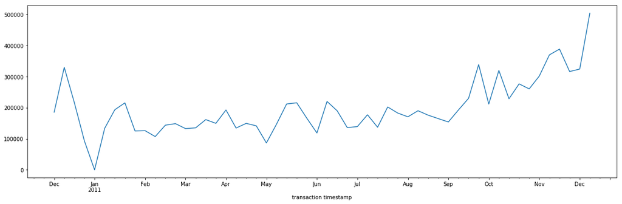

```python
import matplotlib.pyplot as plt
weekly_resampled_data_sum.plot(figsize=(20, 6))
plt.show()
```

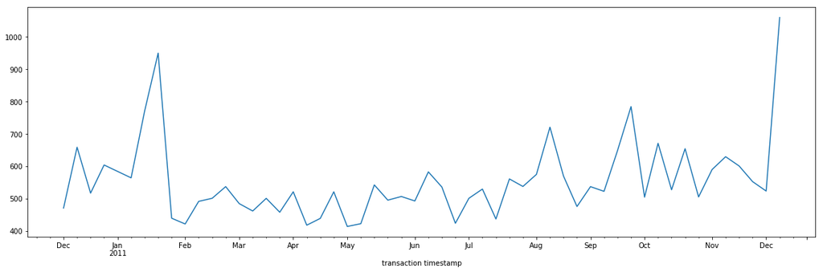

```python
weekly_resampled_data_mean = weekly_resampled_data_mean.interpolate(axis=0)
weekly_resampled_data_mean.plot(figsize=(20, 6))
plt.show()
```

```python
semimonthly_resampled_data_sum = grouped_df['product_price'].resample('MS').sum()
semimonthly_resampled_data_mean = grouped_df['product_price'].resample('MS').mean()
```

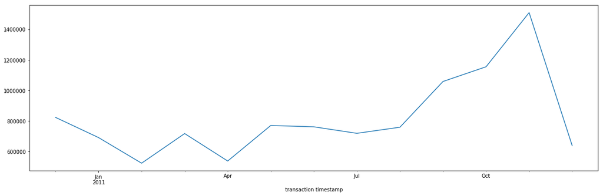

```python
semimonthly_resampled_data_sum.plot(figsize=(20, 6))
plt.show()
```

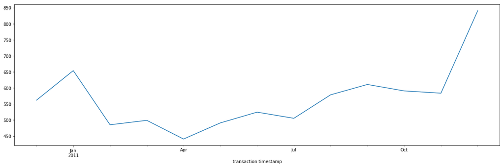

```python
semimonthly_resampled_data_mean.plot(figsize=(20, 6))
plt.show()
```

```python
monthly_resampled_data_sum = grouped_df['product_price'].resample('M').sum()
monthly_resampled_data_mean = grouped_df['product_price'].resample('M').mean()
```

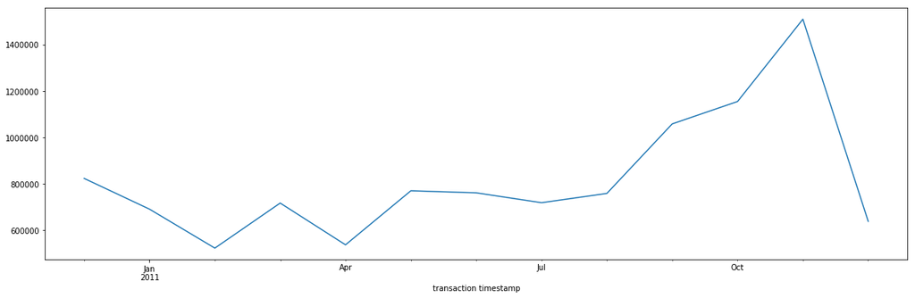

```python
monthly_resampled_data_sum.plot(figsize=(20, 6))
plt.show()
```

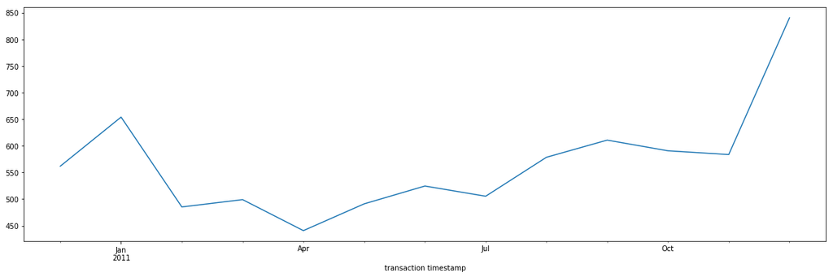

```python
monthly_resampled_data_mean.plot(figsize=(20, 6))
plt.show()
```

## Insights

- Evidently it can be seen that the company performed better with time with a high growth in the fall and winter months
- The same can be accredited with festive season of Christmas and say Thanksgiving
- Althuough with just one year of data, it may be said that the company performed better with time, it must be noted that our inference is limited by performance of corresponding months of different years.It can so happen that the festive season saw more buyers but not the other months.
- To analyse if the company **consistently** performed better, we must look at data which spans a time of more than just a year to have a comparison of quarterly spending across different years.

```python
df = original_df
```

### Extracting the transaction country

Based on the transaction country (for countries where number of transactions is greater than **5000**)

```python
list_of_countries = pd.value_counts(df['transaction country'])
list_of_countries
```

```
United Kingdom          486284
Germany                   9042
France                    8408
EIRE                      7894
Spain                     2485
Netherlands               2363
Belgium                   2031
Switzerland               1967
Portugal                  1501
Australia                 1185
Norway                    1072
Italy                      758
Channel Islands            748
Finland                    685
Cyprus                     614
Sweden                     451
Unspecified                446
Austria                    398
Denmark                    380
Poland                     330
Japan                      321
Israel                     295
Hong Kong                  284
Singapore                  222
Iceland                    182
USA                        179
Canada                     151
Greece                     145
Malta                      112
United Arab Emirates        68
European Community          60
RSA                         58
Lebanon                     45
Lithuania                   35
Brazil                      32
Czech Republic              25
Bahrain                     18
Saudi Arabia                 9
Name: transaction country, dtype: int64
```

```python
united_Kingdom_df = df[df['transaction country']=='United Kingdom']
united_Kingdom_df.head()
```

|  | transaction id | product id | product description | quantity sold | transaction timestamp | unit price | customer id | transaction country | product_price |
| --- | --- | --- | --- | --- | --- | --- | --- | --- | --- |
| 0 | 536365 | 85123A | WHITE HANGING HEART T-LIGHT HOLDER | 6 | 2010-12-01 08:26:00 | 2.55 | 17850.0 | United Kingdom | 15.30 |
| 1 | 536365 | 71053 | WHITE METAL LANTERN | 6 | 2010-12-01 08:26:00 | 3.39 | 17850.0 | United Kingdom | 20.34 |
| 2 | 536365 | 84406B | CREAM CUPID HEARTS COAT HANGER | 8 | 2010-12-01 08:26:00 | 2.75 | 17850.0 | United Kingdom | 22.00 |
| 3 | 536365 | 84029G | KNITTED UNION FLAG HOT WATER BOTTLE | 6 | 2010-12-01 08:26:00 | 3.39 | 17850.0 | United Kingdom | 20.34 |
| 4 | 536365 | 84029E | RED WOOLLY HOTTIE WHITE HEART. | 6 | 2010-12-01 08:26:00 | 3.39 | 17850.0 | United Kingdom | 20.34 |

```python
united_Kingdom_df['transaction timestamp'].min(),united_Kingdom_df['transaction timestamp'].max()
```

```
(Timestamp('2010-12-01 08:26:00'), Timestamp('2011-12-09 12:49:00'))
```

```python
grouped_united_Kingdom_df = united_Kingdom_df.groupby(['transaction timestamp'])['product_price'].sum().reset_index()
grouped_united_Kingdom_df= grouped_united_Kingdom_df.set_index('transaction timestamp')
```

```python
weekly_resampled_data_sum = grouped_united_Kingdom_df['product_price'].resample('W').sum()
weekly_resampled_data_mean = grouped_united_Kingdom_df['product_price'].resample('W').mean()
```

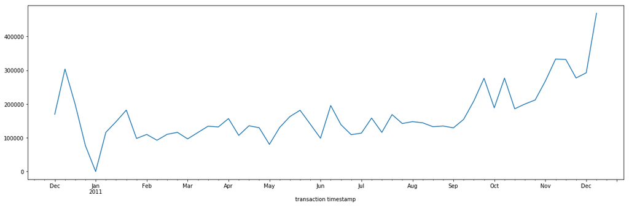

```python
import matplotlib.pyplot as plt
weekly_resampled_data_sum.plot(figsize=(20, 6))
plt.show()
```

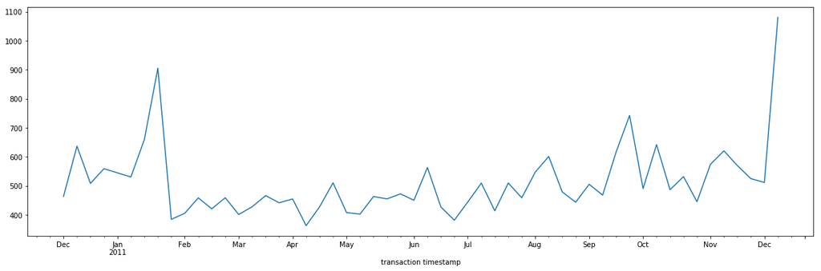

```python
weekly_resampled_data_mean = weekly_resampled_data_mean.interpolate(axis=0)
weekly_resampled_data_mean.plot(figsize=(20, 6))
plt.show()
```

```python
Germany_df = df[df['transaction country']=='Germany']
Germany_df['transaction timestamp'].min(),Germany_df['transaction timestamp'].max()
```

```
(Timestamp('2010-12-01 13:04:00'), Timestamp('2011-12-09 12:16:00'))
```

```python
grouped_Germany_df = Germany_df.groupby(['transaction timestamp'])['product_price'].sum().reset_index()
grouped_Germany_df= grouped_Germany_df.set_index('transaction timestamp')
```

```python
weekly_resampled_data_sum = grouped_Germany_df['product_price'].resample('W').sum()
weekly_resampled_data_mean = grouped_Germany_df['product_price'].resample('W').mean()
```

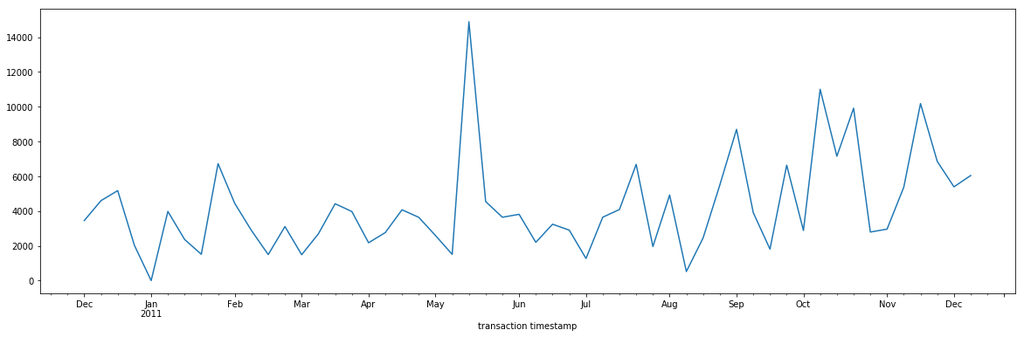

```python
import matplotlib.pyplot as plt
weekly_resampled_data_sum.plot(figsize=(20, 6))
plt.show()
```

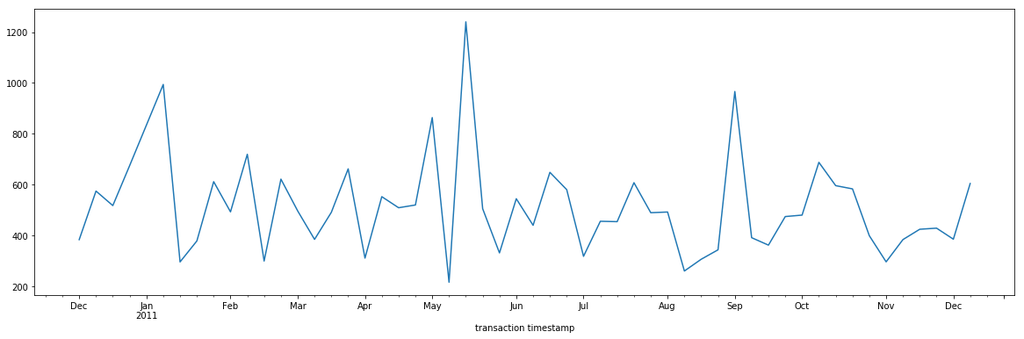

```python
weekly_resampled_data_mean = weekly_resampled_data_mean.interpolate(axis=0)
weekly_resampled_data_mean.plot(figsize=(20, 6))
plt.show()
```

```python
France_df = df[df['transaction country']=='France']
France_df['transaction timestamp'].min(),France_df['transaction timestamp'].max()
```

```
(Timestamp('2010-12-01 08:45:00'), Timestamp('2011-12-09 12:50:00'))
```

```python
grouped_France_df = France_df.groupby(['transaction timestamp'])['product_price'].sum().reset_index()
grouped_France_df= grouped_France_df.set_index('transaction timestamp')
```

```python
weekly_resampled_data_sum = grouped_France_df['product_price'].resample('W').sum()
weekly_resampled_data_mean = grouped_France_df['product_price'].resample('W').mean()
```

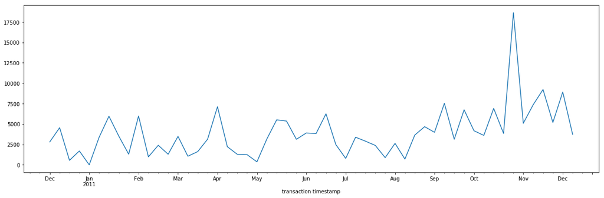

```python
import matplotlib.pyplot as plt
weekly_resampled_data_sum.plot(figsize=(20, 6))
plt.show()
```

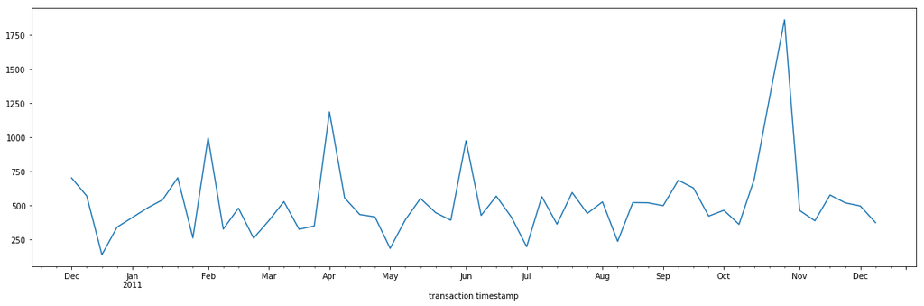

```python
weekly_resampled_data_mean = weekly_resampled_data_mean.interpolate(axis=0)
weekly_resampled_data_mean.plot(figsize=(20, 6))
plt.show()
```

```python
EIRE_df = df[df['transaction country']=='France']
EIRE_df['transaction timestamp'].min(),EIRE_df['transaction timestamp'].max()
```

```
(Timestamp('2010-12-01 08:45:00'), Timestamp('2011-12-09 12:50:00'))
```

```python
grouped_EIRE_df = EIRE_df.groupby(['transaction timestamp'])['product_price'].sum().reset_index()
grouped_EIRE_df= grouped_EIRE_df.set_index('transaction timestamp')
```

```python
weekly_resampled_data_sum = grouped_EIRE_df['product_price'].resample('W').sum()
weekly_resampled_data_mean = grouped_EIRE_df['product_price'].resample('W').mean()
```

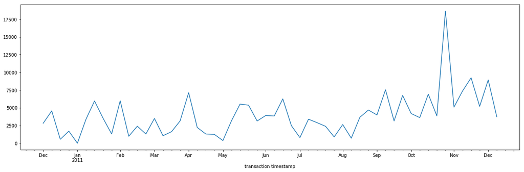

```python
import matplotlib.pyplot as plt
weekly_resampled_data_sum.plot(figsize=(20, 6))
plt.show()
```

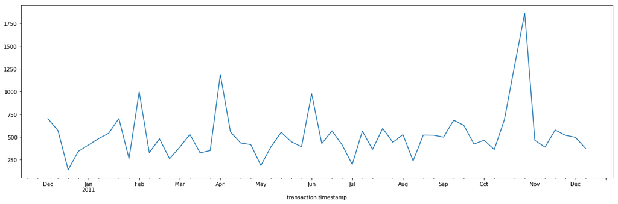

```python
weekly_resampled_data_mean = weekly_resampled_data_mean.interpolate(axis=0)
weekly_resampled_data_mean.plot(figsize=(20, 6))
plt.show()
```

## Insights

- The country level data helps us see that spikes in the expenditure occur at different times in different countries.
- This may provide valuable insights to supply chain and logistics to prepare better for a heavy consumption season.
- Spikes can be related to particular events occuring in that particular country at any point in time.

```python
df = original_df
```

### **Customer Level**

The following analysis is done on customer level to find out the different customers who may be loyal customers to the store. This will help the store determine its customer retention policies.

```python
grouped_df = df.groupby(['customer id'])['transaction timestamp'].unique().reset_index()
grouped_df=grouped_df.set_index('customer id')
grouped_df.index = grouped_df.index.astype('int64')
```

```python
grouped_df['number of transactions']  = grouped_df["transaction timestamp"].apply(lambda x: len(x))
grouped_df['number of transactions'].mean()
```

```
4.2507490205116385
```

It is evident that the average number of transactions per customer in the data i.e., in a period of one year is 4.25

Let us try to explore the number of customers who have a beyond average spending/transaction habit.

```python
grouped_df.shape[0],grouped_df[grouped_df['number of transactions'] > grouped_df['number of transactions'].mean()].shape[0]
```

```
(4339, 1112)
```

The database contains a total of **4339** unique customers out of which **1112** customers can be labelled loyal customers for the store. It can also be inferred that the loyal customers for the store visit it atleast 5 times during a period of one year.

However, to undoubtedly deduce the same would be naive, since a customer could make 5 different transactions in a single day and then not make purchases on different days

```python
grouped_df=grouped_df[grouped_df['number of transactions'] > grouped_df['number of transactions'].mean()]
x = grouped_df['transaction timestamp'].apply(lambda x: np.diff(x).mean())
grouped_df['mean_of_difference_between_transactions'] = x
```

```python
for i, row in grouped_df.iterrows():
    day = grouped_df.at[i,'mean_of_difference_between_transactions'].days
    grouped_df.at[i,'mean_of_difference_between_transactions_day'] = day
grouped_df.drop('mean_of_difference_between_transactions',axis=1,inplace=True)
grouped_df.rename(columns={"mean_of_difference_between_transactions_day": "mean_of_difference_between_transactions"},inplace=True)
```

```python
grouped_df['mean_of_difference_between_transactions'].mean()
```

```
39.57464028776978
```

```python
grouped_df.shape[0],grouped_df[grouped_df['mean_of_difference_between_transactions'] > grouped_df['mean_of_difference_between_transactions'].mean()].shape[0]
```

```
(1112, 525)
```

Again, looking the **1112** customers that had more than average number of transactions i.e., 4.25 ≈ 5, we find only **525** had a mean difference between transaction dates greater than 40 days.

This essentially means that **525** customers out of the total **4339** customers, can be labelled loyal customers, with a sense of surety that these customers visit stores regularly i.e., they visit the store after about **40** days.

```python
df = original_df
```

### Product Level

Let us determine the most popular products by quantity sold.  
This data will help stores stock in adequate quantity and also look for products similar to popular products

```python
grouped_df = df.groupby(['product id'])['quantity sold'].sum().reset_index()
grouped_df=grouped_df.set_index('product id')
```

```python
grouped_df.sort_values('quantity sold',ascending=False,inplace=True, kind='quicksort')
```

```python
grouped_df_2 = df.groupby(['product id'])['product description'].unique().reset_index()
grouped_df_2 = grouped_df_2.set_index('product id')
grouped_df_2['product description'] =  grouped_df_2['product description'].apply(lambda x : x[0])
grouped_df = pd.merge(grouped_df, grouped_df_2, left_on='product id',right_on='product id',how='outer',suffixes=('_left','_right'))
```

```python
grouped_df.head(15)
```

| product id | quantity sold | product description |
| --- | --- | --- |
| 23843 | 80995 | PAPER CRAFT , LITTLE BIRDIE |
| 23166 | 78033 | MEDIUM CERAMIC TOP STORAGE JAR |
| 22197 | 56921 | SMALL POPCORN HOLDER |
| 84077 | 55047 | WORLD WAR 2 GLIDERS ASSTD DESIGNS |
| 85099B | 48478 | JUMBO BAG RED RETROSPOT |
| 85123A | 41664 | WHITE HANGING HEART T-LIGHT HOLDER |
| 84879 | 36461 | ASSORTED COLOUR BIRD ORNAMENT |
| 21212 | 36419 | PACK OF 72 RETROSPOT CAKE CASES |
| 23084 | 31722 | RABBIT NIGHT LIGHT |
| 22492 | 26633 | MINI PAINT SET VINTAGE |
| 22616 | 26339 | PACK OF 12 LONDON TISSUES |
| 21977 | 24854 | PACK OF 60 PINK PAISLEY CAKE CASES |
| 22178 | 24304 | VICTORIAN GLASS HANGING T-LIGHT |
| 15036 | 23826 | ASSORTED COLOURS SILK FAN |
| 17003 | 23056 | BROCADE RING PURSE |

These are 15 most popular products from the prodct category (according to the quantity sold)

#### Some further insights that could be drawn

- Customer buying pattern with respect to dates
- Sale of popular products with respect to dates
- If granularity of data permits to have a feature like category of product, something like a CDI could be introduced.